# Intro to R - Control Flow and Functions

[figure not shown]

# 1 Learning Objectives

**The goal of this chapter is to:**

- Be able to use conditional statements: *if*, *else* and *else if*.
- Be able to use loops: *for* loops and *while* loops
- Learn what functions are.
- Understand why we need to use functions.
- Be able to write functions.
- Have a basic understanding of scoping within functions.

# 2 Loops

Loops are a fundamental concept in traditional programming languages.

> A loop is a way to repeat a number commands until a given condition is met.

Since R is a vectorised language, loops are not as prominently used in R as in Python for example. Despite this, they are key to programming in general and can save you lot’s of time and typing in certain cases.

They allow you to automate parts of your code that are in need of repetition.

Similar to how functions help make our code more abstract and general, loops are similar. As we are essentially simplifying a specific case to a more general case.

We are going to look at two types of loops.

- for loops
- while loops

## 2.1 For Loops

These are the most common types.

They follow the basic structure below,

```r
Basic Structure of a loop

#create an empty output
#which we will fill when the loop runs

output <- c()

#creating the loop

for (Variable in Vector) {

  output <- commands

}
```

- So we start with creating an empty vector for our output

> > Before you start the loop, you should allocate sufficient space for the output.
- And then start with the word `for`
- followed by `()` brackets where we specify an index variable, `i` is commonly used but it can be anything that you want.
- then the word `in`
- then specify an iterable. In this case it is `Vector`, could be a list, dataframe etc
- followed by the `{}` curly brackets, which will have our commands, these could be multiple lines of code.

> An iterable is an object that can be iterated through, one element at a time. Lists and vectors are both iterables.

lets look at an example.

We start by creating an iterable, I have created a vector with **numbers between 0 and 5**.

```r
#Creating a vector

example_vector <- c(0,1,2,3,4,5)
```

Creating our loop.

```r
#create an empty output
#which we will fill when the loop runs

result <- c()

#creating the loop

for (each_number in example_vector) {

    print(each_number*2)

  result <- base::append(result, each_number * 2)

}
```

```
## [1] 0
## [1] 2
## [1] 4
## [1] 6
## [1] 8
## [1] 10
```

```r
#To display the data
result
```

```
## [1]  0  2  4  6  8 10
```

This loop is taking each number in our example vector and multiplying it by 2.

The keyword `for` is followed by a variable that refers to each item in my iterable. I’ve called this variable **each_number** .

> You’ll often see letters like `i` used here.

The keyword in is followed by the iterable I want to loop over (here it is example vector)

My Command are assigned to `result`.The command here is to multiply each number in example vector by 2

> append() function simply adds elements to a vector.

> Loops suppress output, unless explicitly `print()`ed out.

## 2.2 While loops

Our other type of loops are while loops.

For loops iterate a set amount of times, or over a set number of things. A while loop iterates until it no longer meets a certain condition.

```r
#create an empty output
#which we will fill when the loop runs

result <- c()


#creating the loop


while (logical condition) {

  result <- commands

}

#To display the data
result
```

- So we start with creating an empty vector for our output
- Then the word `while`
- followed by the `()` brackets in which we specify our logical condition, using the **conditional operators**.
- and then `{}`, which surrounds our commands. These commands will be run repeatedly in order as long as the specified condtion is `TRUE`.

lets look at an example:

- If we say `stop value` is assigned to 0.
- and we set out condtion to be `stop value < 5`
- then print `stop value`
- and then `add a 1`

```r
#create an empty output
#which we will fill when the loop runs

result <- c()


#Setting the value
stop_value <- 0


#Creating the loop
#Our condition here is that 0<5 i.e stop_value

while (stop_value < 5) {

  print(stop_value)

  stop_value <- stop_value +1

  result <- base::append(result, stop_value+1)
}
```

```
## [1] 0
## [1] 1
## [1] 2
## [1] 3
## [1] 4
```

```r
#To display the data
result
```

```
## [1] 2 3 4 5 6
```

Can you guess what would happen if we removed the `stop_value <- stop_value +1` ?

```r
#create an empty output
#which we will fill when the loop runs
result <- c()


#Setting the value
stop_value <- 0


#Creating the loop
#Our condition here is that 0<5 i.e stop_value

while (stop_value < 5) {

  print(stop_value)

  result <- base::append(result, stop_value+1)
}

#To display the data
result
```

If we removed the code `stop_value <- stop_value +1` , `0` would always be less than `5` and the loop would be stuck in an infinite loop, as R will keep running the code.

> You will have to hit the stop sign to exit the loop.

Although it is useful to know how to use loops in R, it is often faster to accomplish the same thing using vectorised operations in R.

## 2.3 Exercise loops

> While Loop Exercise

### **Exercise**

1. Code a `while` loop with the following characteristics:
- Assign the value of a variable `temperature` to be 40.
- The condition of the `while` loop, should check if the temperature is higher than `20`
- The first command in the body should print out `"Its way too hot!"`
- The next command should decrease the `temperature` by `2` and assign this new value to `temperature` again.

### **Hint**

1. Code a `while` loop with the following characteristics:
- Assign the value of a variable `temperature` to be 40.
- The condition of the `while` loop, should check if the temperature is higher than `20`
- The first command in the body should print out `"Its way too hot!"`
- The next command should decrease the `temperature` by `2` and assign this new value to `temperature` again.

```r
#create an empty output
#which we will fill when the loop runs

result <- c()

#setting the temperature value

temperature <- 40

# Code the while loop
while (condition) {

  conditions

  result <- base::append(result, temperature)

}

#To display the data
result
```

### **Show Answer**

1. Code a `while` loop with the following characteristics:
- Assign the value of a variable `temperature` to be 40.
- The condition of the `while` loop, should check if the temperature is higher than `20`
- The first command in the body should print out `"Its way too hot!"`
- The next command should decrease the `temperature` by `2` and assign this new value to `temperature` again.

```r
#create an empty output
#which we will fill when the loop runs

result <- c()

#setting the temperature value

temperature <- 40

# Code the while loop
while (temperature > 20) {

  print("It way too hot!")

  temperature <- temperature - 2

  result <- base::append(result, temperature)

}
```

```
## [1] "It way too hot!"
## [1] "It way too hot!"
## [1] "It way too hot!"
## [1] "It way too hot!"
## [1] "It way too hot!"
## [1] "It way too hot!"
## [1] "It way too hot!"
## [1] "It way too hot!"
## [1] "It way too hot!"
## [1] "It way too hot!"
```

```r
#To display the data
result
```

```
##  [1] 38 36 34 32 30 28 26 24 22 20
```

# 3 Conditional Statements

A conditional statement will check whether a condition is TRUE or FALSE.

So, if our statement meets this criteria apply this action, otherwise do nothing.

This is useful if we want a function to run only when our data meets certain conditions, this is termed `control flow`.

We use comparison and logical operators.

Comparison Operators

| Operator | Description |
| --- | --- |
| == | equal to |
| != | not equal to |
| < | less than |
| > | greater than |
| <= | less than or eaqual to |
| >= | greater than or equal to |

Logical Operators

| Operator | Description |
| --- | --- |
| & | And |
| \| | Or |
| ! | Not |

You might want an action to be perfomed depending on the outcome, to be able to do this in R, we use the;

- *if* statement
- *else if* statement
- *else* statement

if, elif and else are not loops, but fall under the category of control flow.

These take a conditional argument, and if that is met (evaluates to True) then the associated action is completed.

If the condition is not met it will move to an elif (if present) and if that condition is met the associated action will be completed.

Finally, if none of the conditions are met the actions for the else condition are met.

```r
if (logical condition) {

  Commands - executed if logical condition is true

} else if (second condition) {

  Commands - executed if the logical condition is false and second condtion is true

} else if (third condition) {

  Commands - executed if logical condition and second condition are false

} else {

  Commands - executed when all conditions are false

}
```

> It’s important that the `else if` keyword comes on the same line as the closing bracket of the previous part of the control structure.

We can just have an if and an else.

Lets look at an example.

```r
height <- 6

if (height == 5) {

  print("We're the same height")

} else {

  print("Your height is different")

}
```

```
## [1] "Your height is different"
```

Remember our if, elif and else statements take a contion so we need a double equals sign (==) for checking equivalency. If the first criteria isn’t met it will move to the else statement and action that.

We can add in more choices using an elif statement.

```r
height <- 7

if (height == 5) {

  print("We're the same height")

} else if (height == 7) {

  print("You're tall!")

} else {

  print("Your height is different")

}
```

```
## [1] "You're tall!"
```

Within these we can use our logical operators too - & (and) , | (or).

```r
height <- 9

if (height == 5) {

  print("We're the same height")

} else if (height > 7 & height < 10) {

  print("You're tall!")

} else {

  print("Your height is different")

}
```

```
## [1] "You're tall!"
```

Here we want the action to happen if the value is greater than 7 and less than 10.

```r
height <- 5

if (height == 5) {

  print("We're the same height")

} else if (height > 7 & height < 10) {

  print("You're tall!")

} else if (height == 5) {

  print("Wow, it's still 5!")


} else {

  print("Your height is different")

}
```

```
## [1] "We're the same height"
```

It’s important to know how the if, elif, else works.

Here we have two option for when the value is 5.

However it will only print out “We’re the same height!”

When the condition is met it performs the action associated with it and then quits.

> The case_when() function in dplyr is great for dealing with multiple complex conditions

We can combile a `loop` and and `if else statements`.

```r
number_of_takeaways_ordered <- c(1, 2, 3, 4, 5, 6, 7)

for (i in number_of_takeaways_ordered) {

  if (i > 3) {

    print("too many")

  } else {

  print("enough")

  }

  print(i)

}
```

```
## [1] "enough"
## [1] 1
## [1] "enough"
## [1] 2
## [1] "enough"
## [1] 3
## [1] "too many"
## [1] 4
## [1] "too many"
## [1] 5
## [1] "too many"
## [1] 6
## [1] "too many"
## [1] 7
```

## 3.1 Exercise loops

### **Exercise**

Can you write a loop with an if, elif and else statement, that loops through the numbers from 1 to 30.

If the number is a multiple of both 3 and 5, print FizzBuzz.

If the number is a mutiple of 3, print the word Fizz.

If the number is a mutiple of 5, print the word Buzz.

For all other values print the number.

> > You can use the modulus operator for this - this is the %% in R, and shows us our remainder.

> > item %% 3 == 0

> > to check if it divided completely - having a remainder of 0

```r
# Example of Modulo

10 %% 3 == 0
```

```
## [1] FALSE
```

```r
# Returns False (10 / 3 has a remainder of 1 - so does not have a remainder of 0)
```

```r
# Second example of Modulo

9 %% 3 == 0
```

```
## [1] TRUE
```

```r
# Returns True (9 / 3 has a remainder of 0  )
```

### **Hint**

Can you write a loop with an if, elif and else statement, that loops through the numbers from 1 to 30.

If the number is a multiple of both 3 and 5, print FizzBuzz.

If the number is a mutiple of 3, print the word Fizz.

If the number is a mutiple of 5, print the word Buzz.

For all other values print the number.

```r
for (each_number in vector) {

  if (first conditions) {

    output
  }
  else if (second condition) {

    output
  }
  else if (third condition) {

    output
  }
  else {

    print(each_number)
  }

}
```

### **Show Answer**

```r
for (i in 1:30) {

  if (i %% 3 == 0 & i %% 5 == 0) {

    print("FizzBuzz")
  }
  else if (i %% 3 == 0) {

    print("Fizz")
  }
  else if (i %% 5 == 0) {

    print("Buzz")
  }
  else {

    print(i)
  }

}
```

```
## [1] 1
## [1] 2
## [1] "Fizz"
## [1] 4
## [1] "Buzz"
## [1] "Fizz"
## [1] 7
## [1] 8
## [1] "Fizz"
## [1] "Buzz"
## [1] 11
## [1] "Fizz"
## [1] 13
## [1] 14
## [1] "FizzBuzz"
## [1] 16
## [1] 17
## [1] "Fizz"
## [1] 19
## [1] "Buzz"
## [1] "Fizz"
## [1] 22
## [1] 23
## [1] "Fizz"
## [1] "Buzz"
## [1] 26
## [1] "Fizz"
## [1] 28
## [1] 29
## [1] "FizzBuzz"
```

# 4 Functions

In programming, a named section of a program that performs a specific task is called a function.

Less formally, a functions is a bit of code which, when called, performs a task. They can take various inputs, called arguments, and return outputs.

Base R includes numerous built-in functions and there are thousands more R functions in packages available on CRAN and elsewhere.

We have previously used ready-made functions (from Base R or from packages) In R already, e.g `excel_sheets()`, `help()`,`merge()`,`clean_names()`, `mean()`.

You can also write your own functions, called “user-defined functions”.

## 4.1 Why we use functions

- They make code shorter and easier to understand.
- They make it easier to update code, as we only need to change one place.
- Functions alow us to easily repeat commands.
- They help reduce errors caused from copied and pasted code.

Up until now we’ve been writing code line by line and running it sequentially. As effective as this has been, things can get messy as we scale up to larger problems.

We can avoid messy code by organising it into chunks of reusable code called functions. This allows us to create blocks of code dedicated to performing a specific procedure or task. We can then ‘call’ this function to perform its specific task as and when needed. Understanding why and how to write functions is an important part of writing code that is consistent, readable and reproducible.

In addition to this, we use functions to do everything in R - from making a vector to creating models and plots. Having more hands on experience with functions can give you a greater appreciation for how the functions, we heavily depend on, are implemented.

## 4.2 Types of Functions

In R we have two types of functions:

1. **‘Predefined’ functions**

   We have already used several of these, such as `c()`, `pow()`, `print()`, etc. These functions, like the name suggests are built into R and are always available as we have seen by pressing tab in the console.
2. **User defined Functions**

   These are functions created by us to carry out a specific task. Declared using `function()`.

## 4.3 How to write a function

Basic structure of a function looks like below,

```r
#Basic structure of a function

function_name <- function(input) {

  statements of what the function is doing

  return(the function output)

}
```

> In R, we use a function to make a function!

We use function() to create a function and assign it to the object function_name.

In the same way we use the `list()` function to create and return a list object, the `function()` function will create and return a function object.

The keyword return will return whatever value is after it. When the return statement is executed the function will stop at that line and return the given value.

> No code after the return statement will be executed.

Note that the keyword return is not necessary; but any function without a return statement will return a value of None - it will produce no output for future code to work with.

## 4.4 Examples of basic functions

```r
# Here is a simple function to add together two values and return the sum.

function_sum_values <- function(value_1, value_2) {

  result <- value_1 + value_2

  return(result)

}
```

Our new function `function_sum_values` will exist in our global environment (panel on the right).

Let’s try using the function function_sum_values, we term this calling a function.

### 4.4.1 Calling Functions

Calling user defined functions works the same way as calling the built-in functions we’ve used so far. Simply, type the function name followed by parentheses containing any required parameters.

```r
# I can now run my function

function_sum_values(1,2)
```

```
## [1] 3
```

```r
# Calling the function by itself prints the result to the console


# Alternatively the result can be saved as a new variable

my_result <- function_sum_values(1,2 )

my_result
```

```
## [1] 3
```

### 4.4.2 Functions with Multiple Arguements

Functions can accept as many arguments as you like, but can only output one object (if it is necessary to output more than one object, then the desired outputs can be combined together into a list, and the list can be returned). above is a function that requires two input variables.

Therefore when function_sum_values(1, 2) is called, the arguments are interpreted as value_1 = 1 and value_2 = 2.

Alternatively, if we called called function_sum_values(2, 1) then the arguments would be interpreted as value_1 = 2 and value_2= 1.

### 4.4.3 Named Arguements

For more complicated functions with lots of arguments, specifying the arguments by position becomes more error-prone and harder to understand. Therefore it is often desirable to specify some or all of the arguments by name, then the order of the arguments doesn’t matter:

```r
function_sum_values(value_1 = 1, value_2 = 2)
```

```
## [1] 3
```

## 4.5 Exercise

> Creating Functions Exercise

### **Exercise**

```r
#Creating a vector

age <- c(10, 23, 30,50)

#Calling the range function on the vector
range(age)
```

```
## [1] 10 50
```

Can create a function called my_range which return the difference between the hiegest value and the lowest value?

### **Hint**

```r
#Creating my function

my_range = function(input){

  commands

  return(result)
  }


#To show the difference between the 2 functions
#Running the base R range function
base::range(input)

#Running my custom range function
my_range(input)
```

### **Show Answer**

```r
#Creating my function

my_range = function(age){

  result <-  base::max(age) - base::min(age)

  return(result)
  }

#Running the base R range function
base::range(age)
```

```
## [1] 10 50
```

```r
#Running my custom range function
my_range(age)
```

```
## [1] 40
```

## 4.6 Example

**Pythagoras Function Example**

We are now going to write a function that uses Pythagoras" theorem in order to calculate the hypotenuse (longest side) of a right angle triangle given the two other sides. The equation is given as
$$a^2 + b^2 = c^2$$
where $a$, $b$ are the two known sides and $c$ is the longest side. In order to find the value of $c$ we can rearange the formula to
$$c = \sqrt{a^2 + b^2}$$

The function will input values of $a$ and $b$ and then return the value of $c$ below.

```r
# Function to calculate the value of the hypotenuse
find_the_hypotenuse <- function(a_value, b_value) {

  # Calculate the values of a^2 + b^2
  squared_sum_of_values <- a_value^2 + b_value^2

  # Calculate the value of c using the square root function `sqrt()`
  c_value <- sqrt(squared_sum_of_values)

  # Return the output value of our function.
  return(c_value)
}


# Assign test values to make sure our function works

a_test <- 3
b_test <- 4

# This should give us a value of c = 5

find_the_hypotenuse(a_test, b_test)
```

```
## [1] 5
```

## 4.7 Exercise

> Creating Functions Exercise

### **Exercise**

Write a function which:

1. **Converts from Fahrenheit to degrees Celsius using the equation below.**

$$C=\frac{5}{9}(F-32)$$

> Examples:
- `f_to_c(32)` returns:
  - [1] 0
- `f_to_c(11)` returns:
  - [1] -11.7
- `f_to_c(81.3)` returns:
  - [1] 27.4

### **Hint**

Write a function which:

1. **Converts from Fahrenheit to degrees Celsius using the equation below.**

$$C=\frac{5}{9}(F-32)$$

```r
#Creating our function

Fahrenheit_to_degrees_Celsius <- function(input){

  commands

  return(celsius)
}

#Calling our function
Fahrenheit_to_degrees_Celsius(input)
```

### **Show Answer**

1. **Converts from Fahrenheit to degrees Celsius using the equation below.**

$$C=\frac{5}{9}(F-32)$$

> Examples:
- `f_to_c(32)` returns:
  - [1] 0
- `f_to_c(11)` returns:
  - [1] -11.7
- `f_to_c(81.3)` returns:
  - [1] 27.4

```r
#Creating our function

Fahrenheit_to_degrees_Celsius <- function(fahrenheit){
  celsius <- (5/9)*(fahrenheit - 32)
  return(celsius)
}

#Calling our function
Fahrenheit_to_degrees_Celsius(32)
```

```
## [1] 0
```

# 5 Deeper Understanding

## Arguements

In short, arguments are things you pass to a function, when you call it, to enable the function to perform it’s task.

### Types of Arguements

#### Required Arguments

Like the name suggests, these are arguments which are required by a function and must be passed in the correct order.

```r
#Creating our function
arithmetic <- function(a,b){
  return ((a ^ b)/b)
}

#Calling our function
arithmetic(4,9)
# [1]  29127.11
```

`a` and `b` are both required arguments. We would get a missing error if we did not pass both arguments.

> Also, `arithmetic(a,b) != arithmetic(b,a)` (in most cases!)

#### Default arguments

This is where, in the function declaration, the value of the parameter is pre-set. The function will retain this value unless it is changed when the function is called.

```r
#Creating our function
arithmetic <- function(a,b = 1){
  return ((a ^ b)/b)
}

#Calling our function
arithmetic(5)
# [1]  5

#Calling our function
arithmetic(5,2)
# [1]  12.5
```

In the example above the function will take `a = 5` and use the default value `b = 1`. Where as, in the example below, we overwrite `b = 1` by passing the argument `2`.

#### Dot-dot-dot arguments

> also known as the ellipsis argument.

You will often see in list of arguments a function takes, in the documentation, this `...`. This is a special argument which captures any number of arguments that aren’t otherwise matched.

Sometimes being able to pass an arbitrary number of arguments can be useful, especially when another function is called within a wrapper function. This requires the ellipsis construct, …, which is designed to pass a variable number of arguments to a function. Here’s an example:

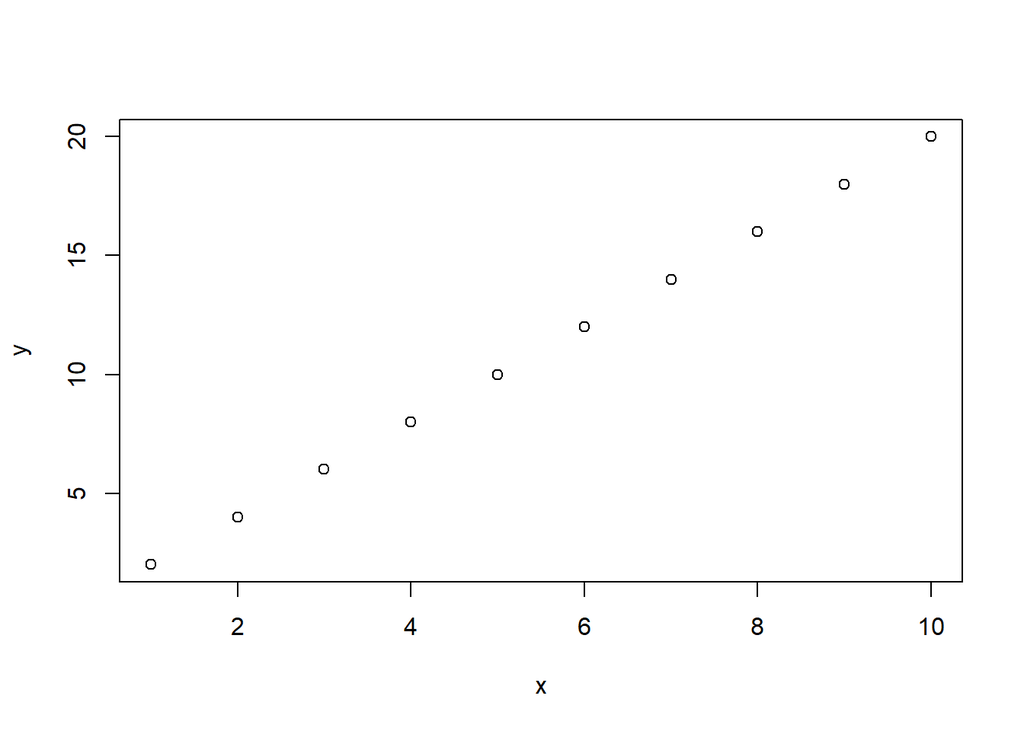

```r
# This function produces a plot of x vs y

plot_x_and_y <- function(x, y, ...) {

  plot(x, y, ...)

}

#Creating Vectors
x <- 1:10

y <- (1:10) * 2


#The function can be called with only the required arguments:

plot_x_and_y(x,y)
```

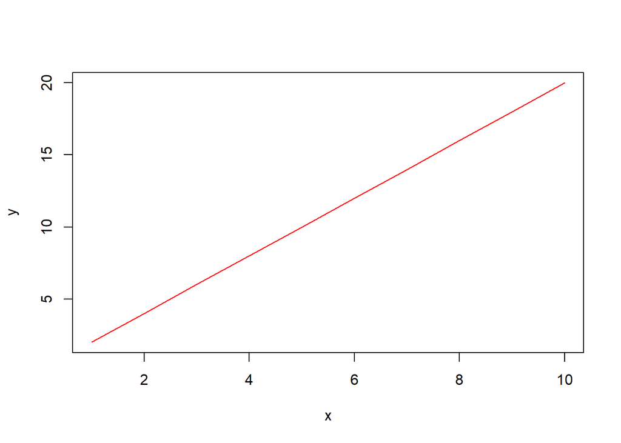

```r
#Or the function can be called with any optional arguments accepted by the plot function:
plot_x_and_y(x, y, col='red', type='l')
```

## 5.1 Scope

It’s important to notice here that the variables I create within my functions are not available outside of my function.

In R storage is broken down into environments and then scopes. Most of the time you’ll be working in the global environment (right hand panel).

In the global environment there are two types of scopes, *global* and *local*. Variables that have *global* scope are visible everywhere - in every function, loop, conditional, basically every part of the code. However, variables that have *local* scope are only visible inside said scope and hence can only be used within that local scope.

When we create a new function we effectively create a new local scope – so the variables we declare within our functions are only available within that local scope.

Here is a classical example to demonstrate this.

```r
#Creating a function

example_function <- function(){
  z <- 10
  paste("This is z inside the function:",z)
}

#Calling a function
example_function()
```

```
## [1] "This is z inside the function: 10"
```

```r
#To display the result
#This will not work as this does not exist outside the function
print(z)
```

# 6 Summary - Control Flow and Functions

## 6.1 Reminder of Learning Objectives

**You should now be able to**

- Be able to use conditional statements: *if*, *else* and *else if*.
- Know what functions are and why they are useful.
- Distinguish between a function’s parameters and arguments.
  - Including different types of arguments
- Understand the idea of ‘scope’.
  - i.e. Global scope vs Local scope
- Write and apply user defined functions.
- Apply functions to `vector` and `tibble` objects.
- Understand programming concept of Loops.
- Utilise loops and understand their place in R.